# Neural Networks Project 2022 - Question 2 Report

## Kondylia Vergou, AM 4325

## Panagiotis Vouzalis, AM 2653

#### Η συγγραφη του κωδικα εγινε σε περιβαλλον Windows

- Για να λειτουργησουν οι εντολες που αναφερονται παρακατω σε περιβαλλον Linux πρεπει να αντικατασταθει το < ; > με < : >
- Τα dependencies της εφαρμογης μας βρισκονται στο φακελο `/jars`
- Αναλογα με τη διαρυθμιση της πλατφορμας που θα τρεξει η εφαρμογη, μπορει να χρειαστει να προστεθει στο τελος του αρχειου προς εκτελεση το επιθεμα `.java` αλλιως πιθανως θα εμφανιζεται ενα σφαλμα τυπου `error: class not found on application class path: <.java file name>`

#### Instructions for Windows Platforms

1. Open terminal inside the directory `Neural Networks - Question 2`
2. Compile with: `javac -cp ".;jars/*" main/*.java`
3. Create a new dataset with: `java -cp ".;jars/*" main/DatasetGenerator` - This is not necessary
4. Run java application with: `java -cp ".;jars/*" main/Kmeans <dataset_name.txt> <number_of_clusters> <number_of_runs>`
- example: `java -cp ".;jars/*" main/Kmeans dataset.txt 9 20`

#### Instructions for Linux Platforms

1. Open terminal inside the directory `Neural Networks - Question 2`
2. Compile with: `javac -cp ".:jars/*" main/*.java`
3. Create a new dataset with: `java -cp ".:jars/*" main/DatasetGenerator` - This is not necessary
4. Run java application with: `java -cp ".:jars/*" main/Kmeans <dataset_name.txt> <number_of_clusters> <number_of_runs>`
- example: `java -cp ".:jars/*" main/Kmeans dataset.txt 9 20`

Για τις αναγκες της δευτερης ασκησης δημιουργησαμε το dataset.txt (παρεχεται και το dataset.csv) συμφωνα με τις απαιτησεις του ερωτηματος Σ2.  
Ο κωδικας για τη δημιουργια του dataset βρισκεται στο αρχειο `/main/DatasetGenerator.java`

# Code overview: /main/Kmeans.java

- Μ ομαδες - το Μ οριζεται απο το χρηστη:  
  `java -cp ".;jars/*" main/Kmeans.java <dataset_name.txt> <number_of_clusters> <number_of_runs>`

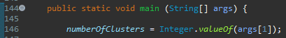

- Φορτωση αρχειου παραδειγματων:

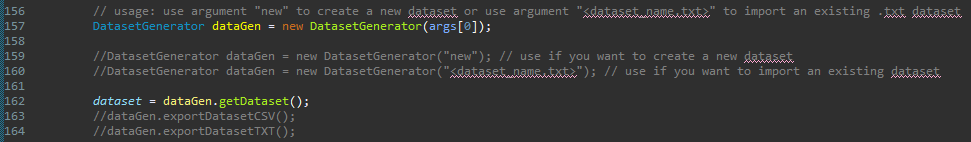

- Data initialization - τυχαια επιλογη αρχικων centroids:

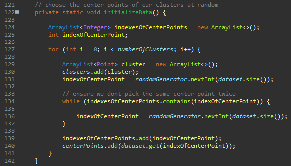

- Υπολογισμος του σφαλματος ομαδοποιησης (ευκλειδια αποσταση) για καθε point και τοποθετηση του point στο συνολο με τη μικροτερη αποσταση απο το κεντρο της αντιστοιχης ομαδας:

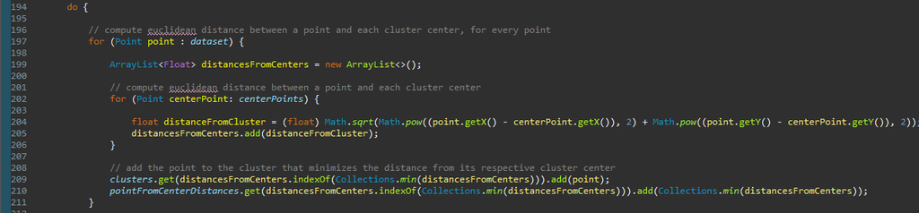

- Υπολογισμος των νεων κεντρων ως προς το μεσο ορο των στοιχειων καθε cluster:

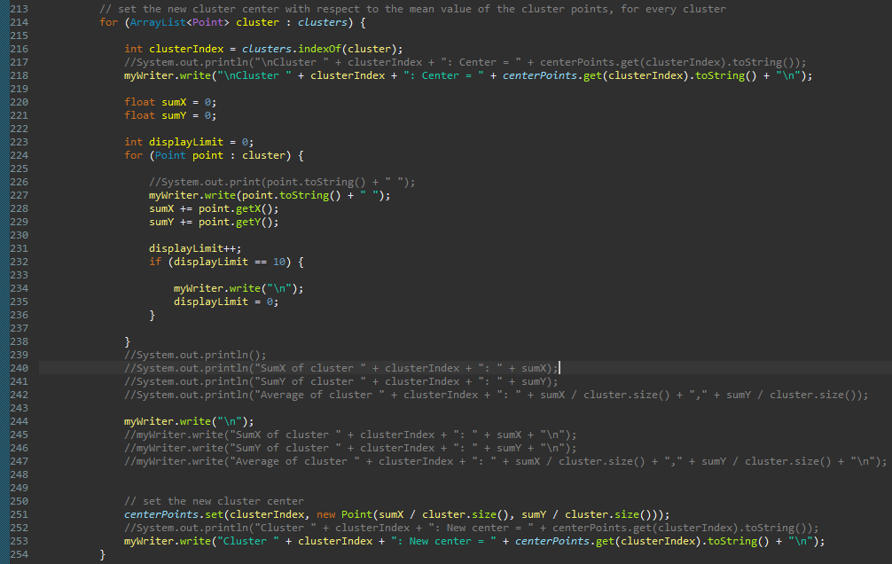

- Ελεγχος τερματισμου βασει της συνθηκης "Εχουν μεταβληθει τα διανυσματα $w_j$ μεταξυ 2 επαναληψεων?":

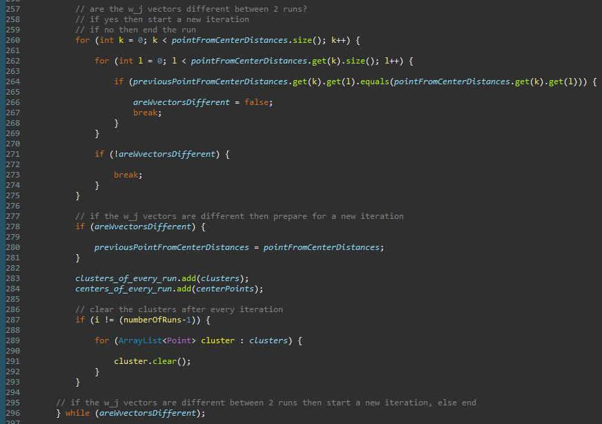

- Υπολογισμος του συνολικου σφαλματος ομαδοποιησης (ευκλειδια αποσταση) για ολα τα clusters:

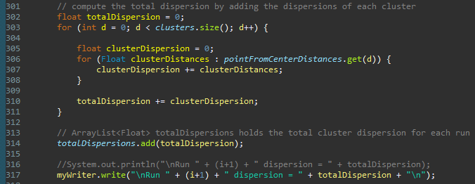

- 20 runs και αποθηκευση της λυσης με το ελαχιστο σφαλμα ομαδοποιησης:  
  `java -cp ".;jars/*" main/Kmeans.java <dataset_name.txt> <number_of_clusters> <number_of_runs>`

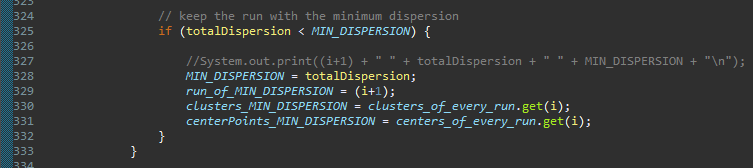

- Αποθηκευση τελικων συντεταγμενων των centroids και του σφαλματος ομαδοποιησης στο αρχειο final_centroids_dispersions (παραδειγμα για 9 clusters και 20 runs):

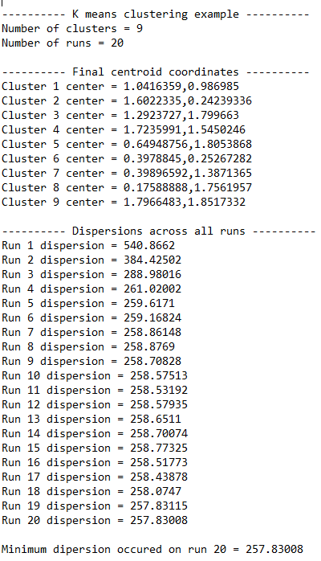

- Δημιουργια plot μεσω του jFreeChart:

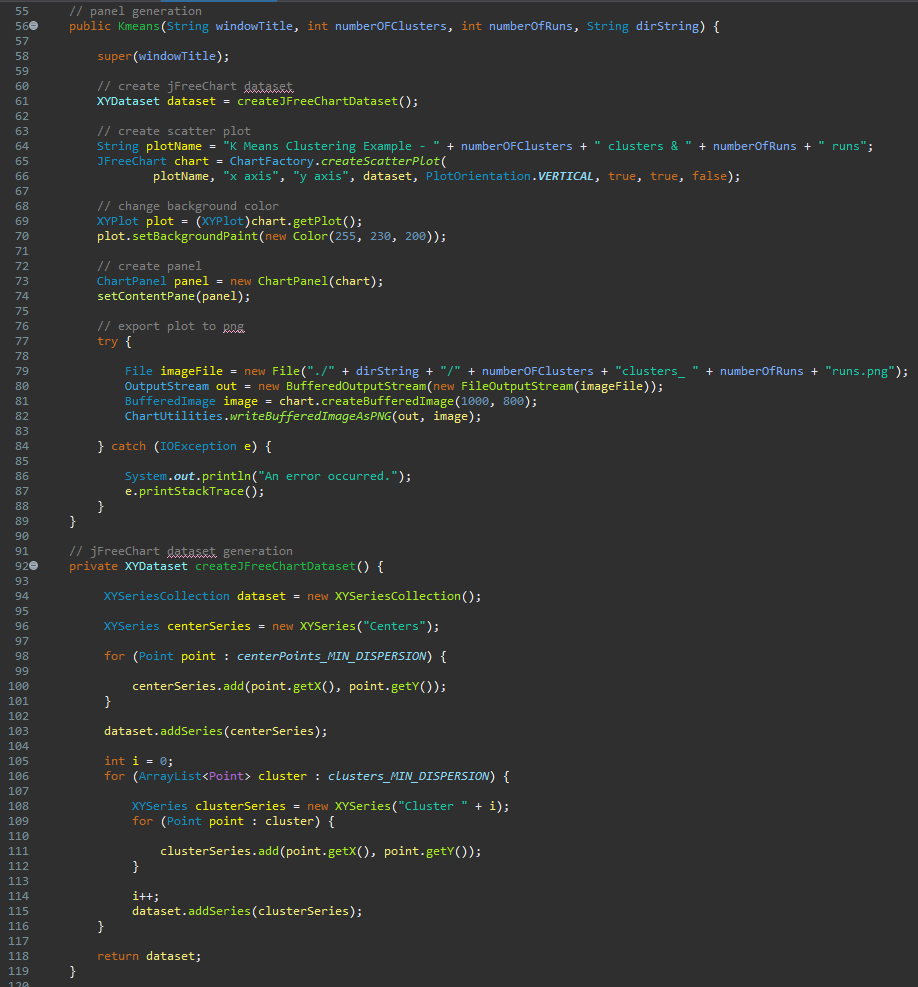

- Δημιουργια γραφικου περιβαλλοντος για το plot:

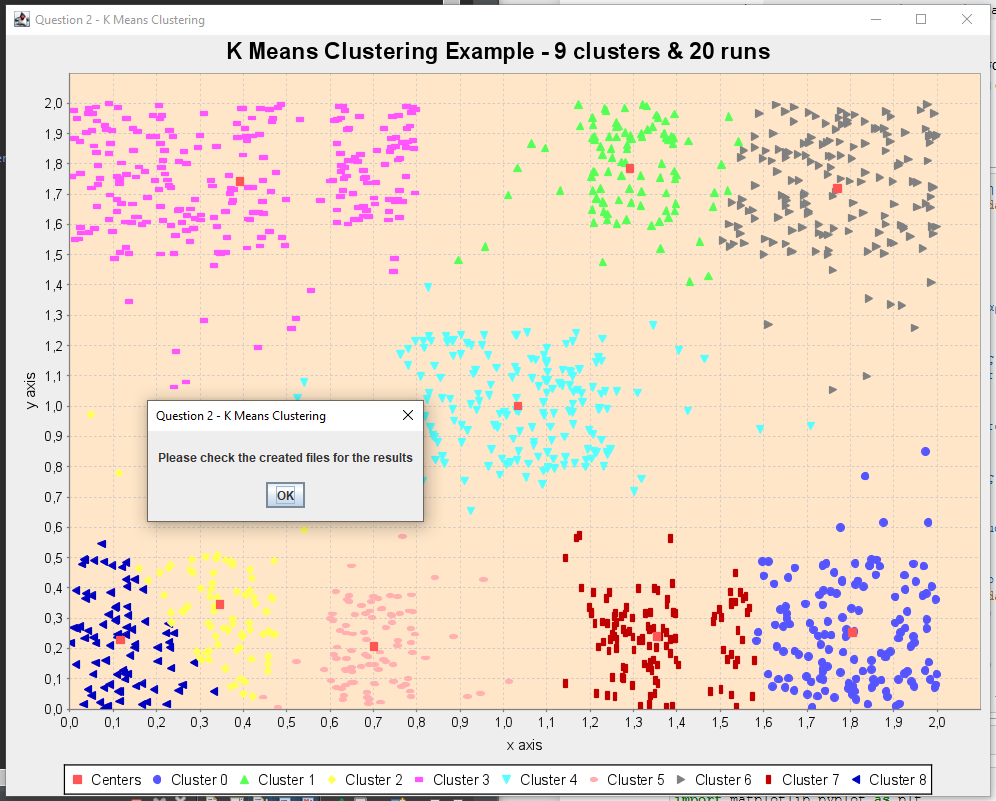

- Αποθηκευση ολων των παραγομενων αρχειων για καθε στο root directory της εφαρμογης, καθε run στο δικο του directory:

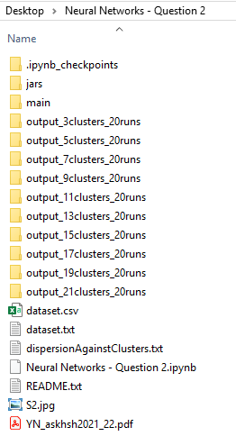

- Παραδειγμα output αρχειων για 9 clusters και 20 runs:
  - Στα αρχεια details_runXX.txt παρεχονται τα centroids, τα clusters, και η ελαχιστη διασπορα για καθε run
  - Αποθηκευση του plot ως .png στο directory με τα outputs

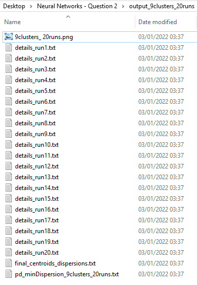

# Mεταβολη του σφαλματος ομαδοποιησης αναλογα τον αριθμο των clusters

```python
import pandas as pd
import matplotlib.pyplot as plt

df = pd.read_csv('dispersionAgainstClusters.txt')
df
```

|  | clusters | min-dispersion |
| --- | --- | --- |
| 0 | 3 | 578.31714 |
| 1 | 5 | 322.40290 |
| 2 | 7 | 271.04608 |
| 3 | 9 | 257.83008 |
| 4 | 11 | 226.77328 |
| 5 | 13 | 217.31060 |
| 6 | 15 | 181.79158 |
| 7 | 17 | 177.68852 |
| 8 | 19 | 164.44003 |
| 9 | 21 | 151.79976 |

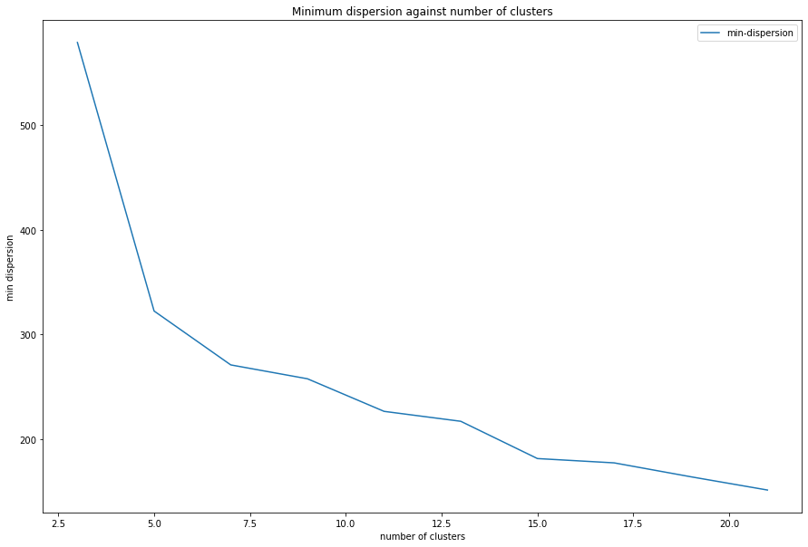

```python
# line plot of min dispersion against clusters
ax = df.plot(x = 'clusters', y = 'min-dispersion', figsize = (15, 10))
ax.set_title('Minimum dispersion against number of clusters')
ax.set_xlabel("number of clusters")
ax.set_ylabel("min dispersion")
```

# Mπορει να χρησιμοποιηθει το σφαλμα ομαδοποιησης για να εκτιμησουμε τον πραγματικο αριθμο των cluster?

Σε γενικες γραμμες ειναι δυνατον να **εκτιμησουμε** τον αριθμο των cluster εαν κανουμε plot το σφαλμα ομαδοποιησης ως προς τις διαφορετικες τιμες του $M$ (αριθμος cluster).

Συνηθως, οσο ο αριθμος $M$ αυξανεται, η αποσταση μεταξυ των points σε καθε cluster μειωνεται.  
Ωστοσο δεν μπορουμε να διαλεξουμε μια αυθαιρετα μεγαλη τιμη του $M$, διοτι ετσι καταληγουμε σε ενα απο δυο πιθανα σεναρια:

1. Eιτε θα υπαρχουν πολλα μικρα cluster με λιγα points
2. Eιτε θα υπαρχουν πολλα cluster με ενα μοναχα point.

Either way, η ολη ιδεα της "ομαδοποιησης" αποδυναμωνεται οσο μεγαλωνει το $M$, για αυτο το λογο θα πρεπει να διαλεξουμε μια "λογικη" τιμη για το $M$.  
Ενας τροπος για να το κανουμε αυτο ειναι να χρησιμοποιησουμε την ιδεα του "γονατου" στο plot και να επιλεξουμε μια τιμη για την οποια το σφαλμα ομαδοποιησης μειωνεται δραματικα.

Εαν **δεν** ειχαμε την πρωτερη γνωση πως ο πραγματικος αριθμος των clusters ειναι 9, **τοτε πιθανοτατα θα επιλεγαμε την τιμη 5** λογω της εντονης πτωσης του σφαλματος.

Η εκφωνηση μας λεει πως ο πραγματικος αριθμος των clusters ειναι 9. Ας το ερευνησουμε:

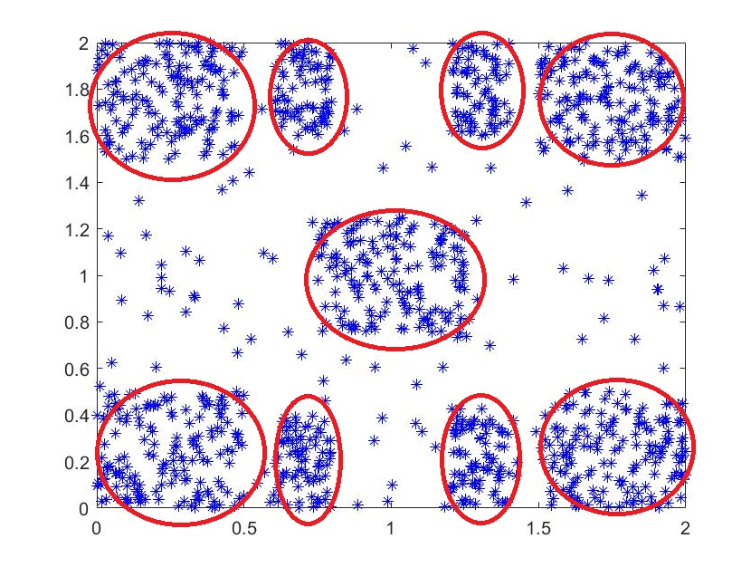

Παρατηρουμε πως υπαρχουν πραγματι 9 clusters στο dataset.

Επιχειρηματολογωντας για την ιδεα της υπαρξης 5 cluster, θα μπορουσε κανεις να πει πως υπαρχουν 5 cluster και να παρουσιασει το παρακατω plot:

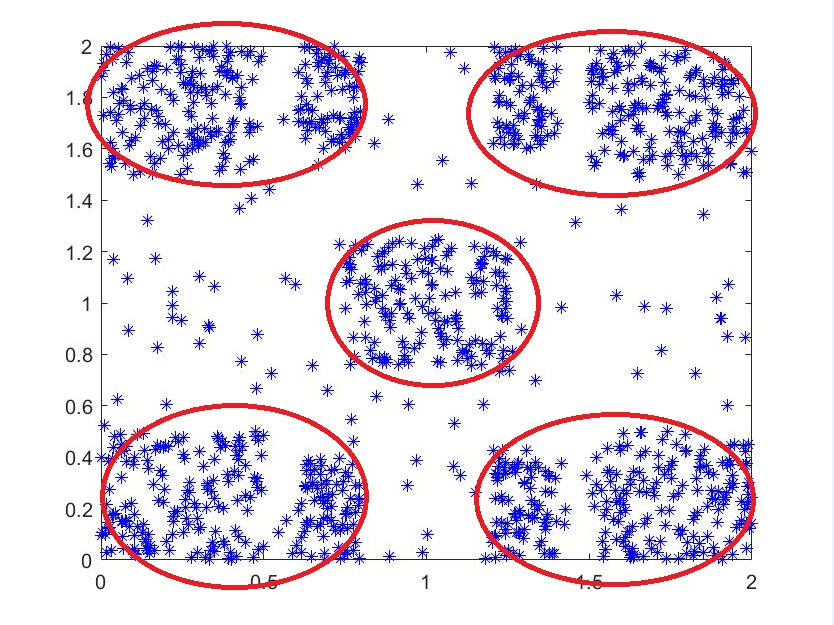

Με τον ιδιο τροπο, θα μπορουσε κανεις να πει επισης πως υπαρχουν 7 clusters, παρουσιαζοντας το παρακατω plot:

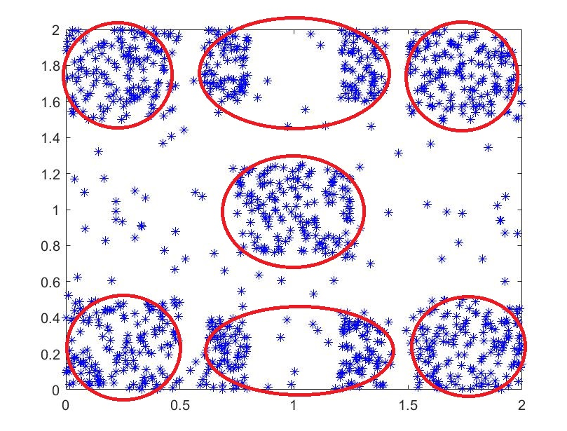

Μονο και μονο παρατηρωντας το παραπανω plot μπορουμε να πουμε με σιγουρια πως ο αριθμος 7 δεν ειναι καλη εκτιμηση του αριθμου των cluster.

# Conclusion

Εαν δε γνωριζουμε τον πραγματικο αριθμο των cluster τοτε μια πολυ καλη εκτιμηση αυτου του αριθμου ειναι να επιλεξουμε ειτε την τιμη $M = 5$ ειτε την τιμη $M = 9$ που ειναι και οι τιμες στα ακρα του "γονατου".

Απο τα παραπανω plots βλεπουμε πως και οι δυο τιμες ειναι "σωστες", ομως απο την εκφωνηση γνωριζουμε εκ των προτερων πως η τιμη $M = 9$ ειναι η περισσοτερο σωστη. Εν τελει, ολα εξαρτωνται απο το ποσο ελαστικοι ειμαστε οσον αφορα την "ομοιογενεια" των cluster που θελουμε να φτιαξουμε (μικροτερη ομοιογενεια $\rightarrow$ 5 clusters, μεγαλυτερη ομοιογενεια $\rightarrow$ 9 clusters).